# Unemployment & Employment Rates in Turkey (2014-2020)

Group Rhapsody

Dec 27, 2020

```r
load(url(paste0("https://github.com/pjournal/mef04g-rhapsody/blob/gh-pages",
                "/Project_Data/project_all_data.RData?raw=true")))
```

## Introduction

Unemployment has become one of the significant problems to be solved in Turkey. Especially, after the opening of numerous universities across the country, there has been an enormous increase in the number of graduates of higher education. However, there are some doubts on the proficiency of these universities due to the high unemployment even for the graduates of higher education. Therefore, in the report, we aimed to approach unemployment for the graduates of higher education. In the first part, there is an overview of the overall unemployment in Turkey and the unemployment numbers by gender. In the second part, we studied both employment and unemployment for different educational levels achieved. Here, you can find both employment and unemployment distribution of different educational groups. Then, we studied the graduates of the higher education under 22 different majors. Both unemployment rates by each major and the trend are provided. In the last part, job searching channels are examined for further information about the trends on job application channels among unemployed people.

## Outcomes

### Overview Regarding Unemployment in Turkey (2014-2020)

After visualization of the Unemployed Job Searching People by the Channel dataset, the seasonal effect in unemployment has became evident by year after year on graph despite the yearly increase in total unemployment. As a result of major events in 2016 and 2018, there can be seen a significant increase on unemployment in these years.

When we examine our data by gender, male workers have been effected more than women in percentage from the unemployment increase in 2018 which is triggered by the depreciation of Turkish Lira.

Based on the yearly unemployment distribution by gender, we can see the similar movements on both genders has interrupted only one time in 2020. This can be caused by the more participation of female workers in seasonal jobs.

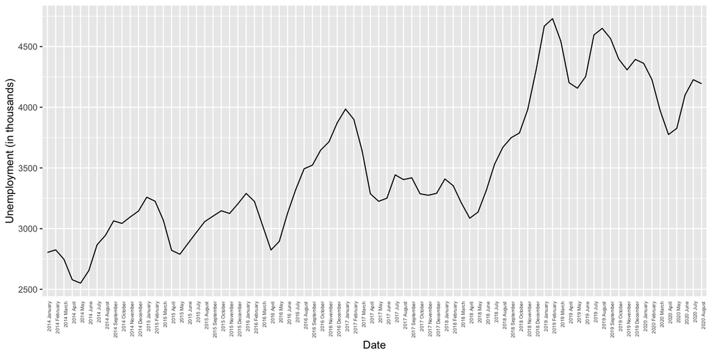

```r
occ_group_overall_m <- occ_group_overall %>%
  filter(month != "Annual") %>%
  mutate(year = factor(year),
         month = factor(month, levels = c("January","February", "March", "April", "May",
                                          "June", "July", "August", "September",
                                          "October", "November", "December")))

occ_group_overall_m <- occ_group_overall_m %>%
  mutate(date = factor(paste(year, month), levels = paste(year, month)))

ggplot(occ_group_overall_m, aes(date, total_unemployed)) +
  geom_line(aes(group = 1)) +
  labs(
    x = "Date",
    y = "Unemployment (in thousands)") +
  theme(axis.ticks.x = element_blank(),
        axis.text.x = element_text(angle = 90, size = 5,  hjust = 1))
```

### Unemployment by Gender

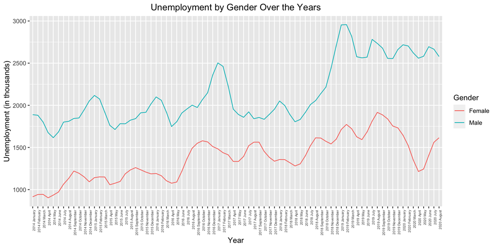

```r
monthly_jobsearch_male <- filter(job_search_male, !grepl("Annual", month))
monthly_jobsearch_female <- filter(job_search_female, !grepl("Annual", month))

unemp_gr_male<-monthly_jobsearch_male%>%
  transmute(month_year = paste(year, month, sep = " "), total_unemployed)

unemp_gr_female<-monthly_jobsearch_female%>%
  transmute(month_year = paste(year, month, sep = " "), total_unemployed)


unemp_merged <-merge(unemp_gr_female,unemp_gr_male, by="month_year",
                     all=TRUE, sort = FALSE)

unemp_merged <- unemp_merged %>%
  rename(female=total_unemployed.x, male=total_unemployed.y)

unemp_merged$month_year <- as.character(unemp_merged$month_year)
unemp_merged$month_year <- factor(unemp_merged$month_year, level=unemp_merged$month_year)

ggplot(unemp_merged, aes(x=factor(month_year))) +
  geom_line(aes(y=female, color="Female", group=1))+
  geom_line(aes(y=male, color="Male", group=1))+
  theme(axis.text.x = element_text(angle=90, size=5, hjust = 1),
        plot.title = element_text(hjust = 0.5))+
  labs(title = "Unemployment by Gender Over the Years",
       x="Year",
       y="Unemployment (in thousands)",
       color="Gender")
```

### Employed & Unemployed by Educational Level

```r
yearly_educational <- filter(educational_level_overall, grepl("Annual", month))
total_labour_yearly_educational <- yearly_educational%>%
  transmute(year=as.character(year),illeterate=lf_illeterate, less_than_hs=lf_less_than_hs, highschool=lf_highschool, voc_hs=lf_voc_hs, higher_ed=lf_higher_ed)

total_labour_yearly_educational_melt <- total_labour_yearly_educational %>%
  gather(key="type", value="value", -year) %>%
  group_by(year) %>%
  mutate(Percentage= round(value/sum(value) * 100, 1))


emp_yearly_educational <- yearly_educational %>%
  transmute(year=as.character(year), illeterate=emp_illeterate, less_than_hs=emp_less_than_hs, highschool=emp_highschool, voc_hs=emp_voc_hs, higher_ed=emp_higher_ed)

emp_yearly_educational_melt<-emp_yearly_educational %>%
  gather(key="Education_Level", value="Person", -year ) %>%
  group_by(year) %>%
  mutate(Percentage= round(Person/sum(Person) * 100, 1))

emp_yearly_educational_melt$Education_Level <- as.factor(emp_yearly_educational_melt$Education_Level)
levels(emp_yearly_educational_melt$Education_Level) <- c("Higher Education", "Highschool", "Illeterate", "Less Than Highschool", "Vocational Highschool")

unemp_yearly_educational <- yearly_educational %>%
  transmute(year=as.character(year), illeterate=unemp_illeterate, less_than_hs=unemp_less_than_hs, highschool=unemp_highschool, voc_hs=unemp_voc_hs, higher_ed=unemp_higher_ed)

unemp_yearly_educational_melt<-unemp_yearly_educational %>%
  gather(key="Education_Level", value="Person", -year ) %>%
  group_by(year) %>%
  mutate(Percentage= round(Person/sum(Person) * 100, 1))

unemp_yearly_educational_melt$Education_Level <- as.factor(unemp_yearly_educational_melt$Education_Level)
levels(unemp_yearly_educational_melt$Education_Level) <- c("Higher Education", "Highschool", "Illeterate", "Less Than Highschool", "Vocational Highschool")
```

The employment rate for Higher Education category has increased from 19.6% to 25.3% in six years. On the other hand the unemployment rates has reached to 26.9% in 2018 and then has dropped to 25.1% in 2019. On the other side of the coin, both rates for people who owning less than a highschool degree has decreased respectively from 56.2% to 50.4% and from 53.1% to 48.3%. This can be interpreted as; the proportion of people that owning a higher education degree getting bigger by years and, the proportion of the people who have a less than a highschool degree getting smaller in total workforce. Thus, the proportion of “Higher Education” group in employment will surpass the “Less Than Highschool” group roughly in ten years.

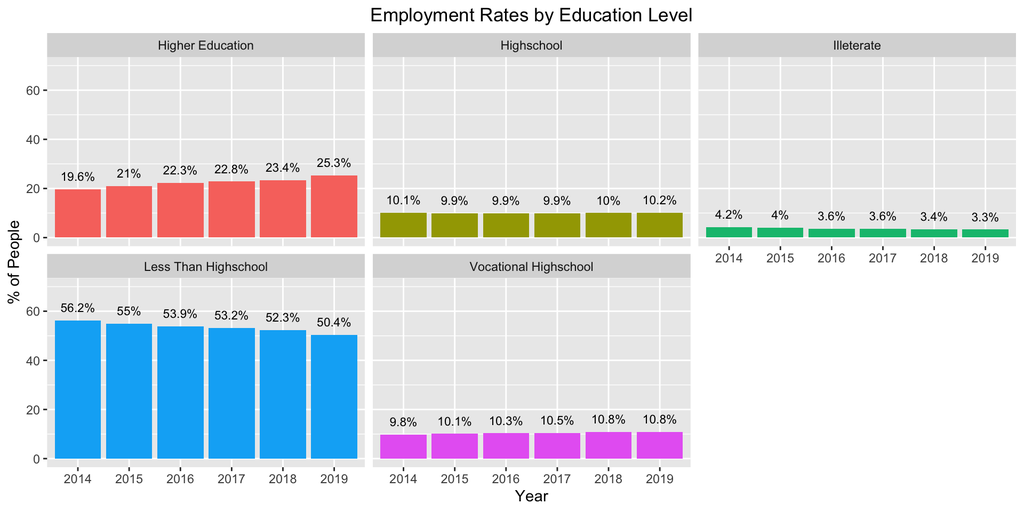

```r
#Employment Graph
ggplot(emp_yearly_educational_melt, aes(x = year, y = Percentage)) +
  geom_bar(stat = "identity", aes(fill = as.factor(Education_Level))) +
  coord_cartesian(ylim=c(0,70))+
  geom_text(aes(label = paste0(Percentage, "%"), vjust = -1), size = 3) +
  facet_wrap(~ Education_Level)+
  labs(title="Employment Rates by Education Level",
       x="Year",
       y="% of People")+
  theme(legend.position = "none",  plot.title = element_text(hjust = 0.5))
```

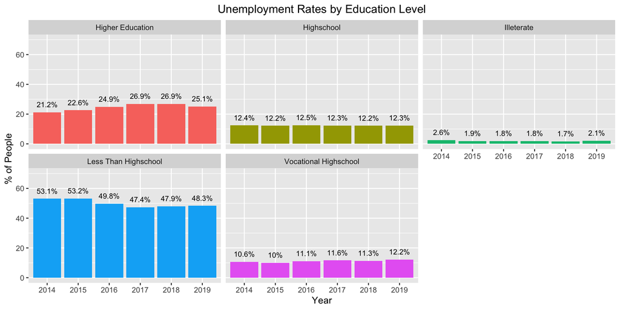

```r
#Unemployment Graph
ggplot(unemp_yearly_educational_melt, aes(x = year, y = Percentage)) +
  geom_bar(stat = "identity", aes(fill = as.factor(Education_Level))) +
  coord_cartesian(ylim=c(0,70))+
  geom_text(aes(label = paste0(Percentage, "%"), vjust = -1), size = 3) +
  facet_wrap(~ Education_Level)+
  labs(title="Unemployment Rates by Education Level",
       x="Year",
       y="% of People")+
  theme(legend.position = "none",  plot.title = element_text(hjust = 0.5))
```

### Unemployment of Higher Education Graduates by Their Major

There are 4 majors having negative trend, which means that unemployment rates for these majors have decreased from 2014 to 2019. These majors are Journalism & Information (-25.3%), Personal Services (-15.1%), Biology and Environmental Sciences (-1.1%), and Information and Communication Technologies (-0.6%). However, after analyzing the unemployment rates carefully, we observed that some of these majors are also the one of the majors with the highest unemployment rate. For example, unemployment rates for the graduates of Journalism & Information are 29.17% and 21.8% for 2014 and 2019, respectively. Therefore, even such a huge decrease in unemployment rate does not ensure finding a suitable job.

On the other hand, the same applies to the majors with the highest trends. For example, Health has the highest trend with an increase of 262.7% in unemployment rate. However, the unemployment rates for Health are 3.14% for 2014 and 11.4% for 2019. Therefore, even if Health has the highest increase in percentage, it can still be seen as one of the majors with the lowest unemployment rate.

All in all, trend column in the table provides an overview of the percentage change in unemployment rates for each major. However, since some majors with highest unemployment rate might have a bad reputation among the public, people may avoid studying these majors, which may decrease the unemployment rate. The same applies vice-versa. Majors with the lowest unemployment rate might have a good reputation and there might be an increased tendecy to study these majors, which might increase the number of graduates and the unemployment rate. Therefore, when analyzing the table below, it will give more reliable results when analyzing both unemployment rates and the trends together.

```r
deneme_major <- last_graduated_major %>%
  gather(key = "Major", value = "value", -year, -statistics)

deneme_major_issizoran <- filter(deneme_major, grepl("İşsizlik oranı", statistics))

major_issizoran_wide <- spread(deneme_major_issizoran, year, value) %>%
  subset(select = -c(statistics))

major_issizoran_wide$Trend <-
  round(((major_issizoran_wide$`2019`/major_issizoran_wide$`2014`)-1)*100,1)

major_issizoran_wide$Major <- as.factor(major_issizoran_wide$Major)
levels(major_issizoran_wide$Major) <-
  c("Agriculture, forestry and fishery","Architecture and construction",
    "Arts", "Biology & Env. Sci.", "Business & Admin.", "Education",
    "Engineering and engineering trades", "Health",
    "Higher education graduate", "Humanities", "Info. & Comm. Tech.",
    "Journalism & Info.", "Languages", "Law", "Manufacturing and processing",
    "Mathematics and statistics", "Occupational health and transport services",
    "Personal Services", "Physical science", "Security Services",
    "Social and behavioural sciences", "Veterinary",
    "Welfare (Social services)")

major_top5 <- major_issizoran_wide %>%
  top_n(5, Trend)

major_last5 <- major_issizoran_wide %>%
  arrange(Trend) %>%
  head(5)

kable(mutate(major_issizoran_wide, across(where(is.numeric), round, 1)))
```

| Major | 2014 | 2015 | 2016 | 2017 | 2018 | 2019 | Trend |
| --- | --- | --- | --- | --- | --- | --- | --- |
| Agriculture, forestry and fishery | 11.6 | 15.3 | 12.7 | 12.4 | 12.0 | 14.6 | 25.6 |
| Architecture and construction | 10.9 | 10.2 | 12.6 | 13.5 | 13.7 | 18.0 | 65.6 |
| Arts | 16.3 | 16.2 | 21.2 | 20.4 | 17.8 | 19.7 | 20.8 |
| Biology & Env. Sci. | 14.7 | 20.2 | 14.1 | 16.0 | 16.9 | 14.5 | -1.1 |
| Business & Admin. | 13.6 | 13.3 | 13.8 | 13.2 | 13.3 | 14.3 | 4.8 |
| Education | 7.4 | 7.8 | 8.6 | 9.7 | 9.8 | 10.2 | 38.2 |
| Engineering and engineering trades | 8.8 | 8.8 | 9.4 | 9.0 | 10.3 | 12.1 | 38.1 |
| Health | 3.1 | 5.0 | 6.3 | 9.6 | 9.6 | 11.4 | 262.7 |
| Higher education graduate | 10.6 | 11.0 | 12.0 | 12.7 | 12.4 | 13.7 | 28.7 |
| Humanities | 6.7 | 9.0 | 10.5 | 13.2 | 13.2 | 15.8 | 135.6 |
| Info. & Comm. Tech. | 16.8 | 17.1 | 17.0 | 19.9 | 14.0 | 16.7 | -0.6 |
| Journalism & Info. | 29.2 | 17.4 | 19.2 | 19.1 | 23.8 | 21.8 | -25.3 |
| Languages | 8.1 | 10.7 | 13.8 | 16.4 | 14.9 | 14.7 | 81.3 |
| Law | 7.3 | 6.8 | 6.0 | 11.2 | 8.3 | 8.4 | 14.5 |
| Manufacturing and processing | 13.2 | 12.3 | 18.4 | 14.2 | 11.9 | 17.1 | 29.8 |
| Mathematics and statistics | 9.3 | 9.7 | 14.1 | 14.0 | 9.9 | 12.6 | 35.4 |
| Occupational health and transport services | 12.5 | 18.8 | 23.5 | 18.0 | 17.0 | 18.6 | 48.8 |
| Personal Services | 12.9 | 15.4 | 16.7 | 14.3 | 12.2 | 11.0 | -15.1 |
| Physical science | 14.3 | 12.7 | 12.0 | 15.7 | 16.9 | 16.5 | 15.5 |
| Security Services | 2.5 | 3.3 | 4.7 | 5.0 | 6.3 | 5.8 | 130.1 |
| Social and behavioural sciences | 11.2 | 11.6 | 13.5 | 15.2 | 15.3 | 16.1 | 43.8 |
| Veterinary | 6.7 | 8.2 | 7.3 | 10.7 | 8.9 | 11.2 | 68.0 |
| Welfare (Social services) | 19.2 | 23.8 | 24.0 | 26.4 | 24.3 | 24.0 | 24.8 |

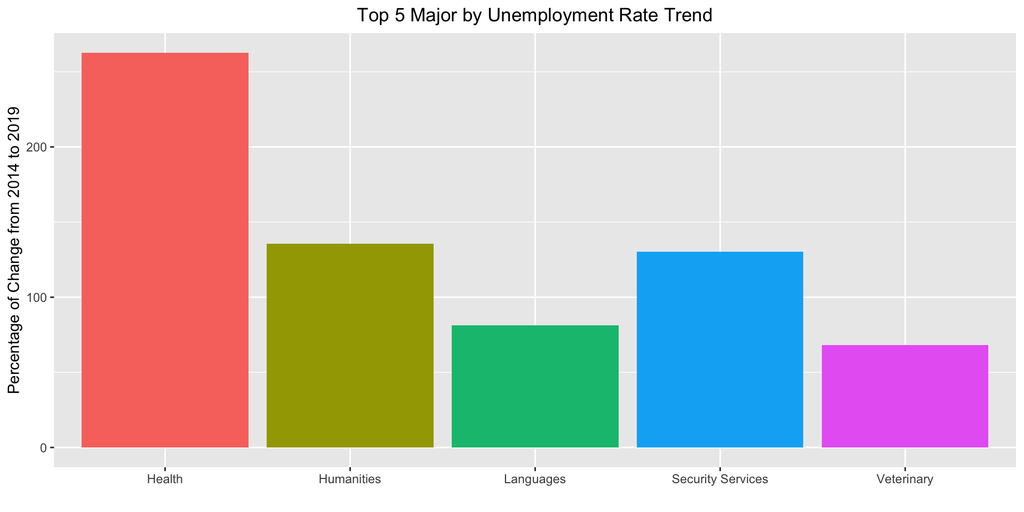

```r
ggplot(major_top5, aes(factor(Major, levels = Major), Trend, fill = Major)) +
  geom_col(position = "dodge") +
  theme(legend.position = "none",
        plot.title = element_text(hjust = 0.5))  +
  guides(fill=guide_legend(title="Major")) +
  labs(x = "",
       y = "Percentage of Change from 2014 to 2019",
       title = "Top 5 Major by Unemployment Rate Trend")
```

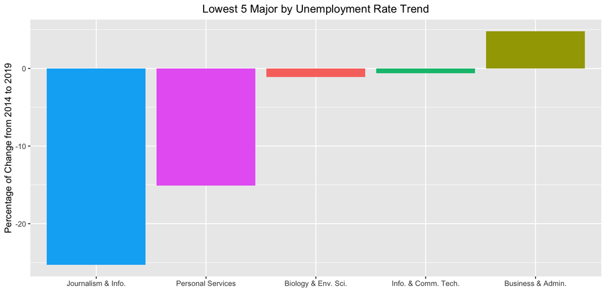

```r
ggplot(major_last5, aes(factor(Major, levels = Major), Trend, fill = Major)) +
  geom_col(position = "dodge") +
  theme(legend.position = "none",
        plot.title = element_text(hjust = 0.5))  +
  guides(fill=guide_legend(title="Major")) +
  labs(x = "",
       y = "Percentage of Change from 2014 to 2019",
       title = "Lowest 5 Major by Unemployment Rate Trend")
```

### Unemployed Job Searching People by the Channel

In these six charts, job searching channels were analyzed between the years 2014 and 2019. When we look at the change in percentage of job searching channels, it is clearly seen that job applications percentage has increased through Turkish Employment Office. It was 14.2% in 2014 and rose up to 24.3% in 2019. Also, applications through Employment Agencies were 6.3% in 2014 and rose 10.1% in 2019.

On the other hand, Direct applications to Employers, application with newspapers and searching job by asking friends and relatives has decreased in this period. Direct applications to Employers percentage were 26.1% in 2014 and decreased 21.9% in 2019. We think that the main reason for the decrease in the percentage of applying jobs listed in newspapers is the change in job searching trend. Clearly, applying for jobs through websites and mobile apps has become a much easier and dynamic way of the job application process. So, the percentage of job applications through newspapers was 15.5% in 2014 and decreased to 10.4% in 2019.

Although the number of higher education graduates have increased during the same period (2014-2019), our data indicate that there has been a decline in job applications that are sent directly to employers. Instead, applications through the Turkish Employment Office and Agency (ISKUR) have seen a rise. This is the opposite of the expectations—that the higher education graduates would not need to apply through the Turkish Employment Office and Agency.

To sum up, those who cannot find jobs on their own apply for a job through ISKUR or other private employment agencies regardless of their graduation levels.

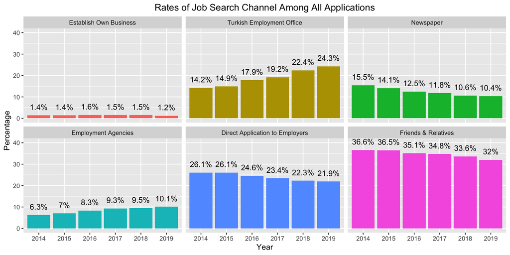

```r
job_search_overall_c <- job_search_overall %>%
  filter(month == "Annual") %>%
  mutate(year = factor(year),
         establish_own_bus = look_place_equip_to_est_bus + look_credit_license_to_est_bus,
         newspaper = to_newspaper + insert_ad_to_newspaper,
         iskur = to_emp_office + wait_call_from_emp_office,
         waiting_result = wait_result_of_app + wait_result_of_comp_for_public_sec) %>%
  select(year, establish_own_bus, newspaper, iskur,
         to_emp_agencies, to_employers, to_relatives)

Year <- rep(unique(job_search_overall_c$year), times = (ncol(job_search_overall_c)-1))

Channel <- rep(colnames(job_search_overall_c[-c(1,1)]),
               each = length(unique(Year)))

Count <- array(unlist(job_search_overall_c[1:6,2:7]))

js_df <- data.frame(Year, Channel, Count)

js_df_rate <- js_df %>%
  group_by(Year) %>%
  mutate(Percentage = round(Count/sum(Count) * 100, 1))

js_df_rate$Channel <- as.factor(js_df_rate$Channel)

levels(js_df_rate$Channel) <- c("Establish Own Business", "Turkish Employment Office",
                                "Newspaper","Employment Agencies",
                                "Direct Application to Employers",
                                "Friends & Relatives")

ggplot(js_df_rate, aes(x = Year, y = Percentage)) +
  geom_bar(stat = "identity", aes(fill = as.factor(Channel))) +
  geom_text(aes(label = paste0(Percentage, "%"), vjust = -1)) +
  facet_wrap(~Channel) +
  ggtitle("Rates of Job Search Channel Among All Applications") +
  theme(legend.position = "none",  plot.title = element_text(hjust = 0.5)) +
  scale_y_continuous(limits = c(0,40))
```

## References

- [Unemployed Job Searching People by the Channel Dataset](https://data.tuik.gov.tr/Bulten/DownloadIstatistikselTablo?p=YD6JGk3HAkwb1wQadeYsjp8iMZJ1cmLtRnMCRXPG3aOudsWPijD1R0XxxA54Ehu8)
- [Employed & Unemployed by Educational Level Dataset](https://data.tuik.gov.tr/Bulten/DownloadIstatistikselTablo?p=bWJMnEy0j6UZHm1gD5qqGkGNWSNKDEJ4I57rthEhkNd9qHF6QHUpwQl25NrXRpAg)
- [Unemployment by Occupational Group Dataset](https://data.tuik.gov.tr/Bulten/DownloadIstatistikselTablo?p=VyBwucwx3Wx2uJXGxoM3soWzPxQv5BRhYRELMU0FhptFZ5Ythna2czyzH6s4rDxR)
- [Unemployment of Higher Education Graduates by Major Dataset](https://data.tuik.gov.tr/Bulten/DownloadIstatistikselTablo?p=vLICiE6Ol0yQYtmtU/kJ2JEnAr8Q14emL5iDhwHMpzChnPnzsVhz1tXV3REhaV9R)
- [Reading .xls Files From URL](https://github.com/tidyverse/readxl/issues/183)
- [Creating .Rdata Files](https://bookdown.org/ndphillips/YaRrr/rdata-files.html)
- [Filling Empty Values with Previous Values in a Column](https://stackoverflow.com/questions/40040834/replace-na-with-previous-or-next-value-by-group-using-dplyr/40041172)
- [Adding Data Labels to Plot](https://www.r-bloggers.com/2020/04/adding-labels-to-a-ggplot2-bar-chart/)
- [Creating Percent Stacked Bar Chart](https://www.r-graph-gallery.com/48-grouped-barplot-with-ggplot2.html)
- [Loading .Rdata Files](https://stackoverflow.com/questions/26108575/loading-rdata-files-from-url)
- [Justify Text in RMarkdown](https://stackoverflow.com/questions/43222169/how-to-justify-the-text-to-both-sides-when-knitting-html-in-rmarkdown)

Go to [group’s progress journal.](https://pjournal.github.io/mef04g-rhapsody/)